# Data Analysis and Lab HW2

Na SeungChan

2023-12-01

Step 1.

```r
df <- NHANES %>%
  mutate(male = ifelse(Gender == 'male', 1, 0), white = ifelse(Race1 == 'White', 1, 0), black = ifelse(Race1 == 'Black', 1, 0), hs = ifelse(Education == 'High School'|Education == 'Some College'|Education == 'College Grad', 1, 0), income_high = ifelse(HHIncome == "75000-99999"|HHIncome == "more 99999", 1, 0), income_low = ifelse(HHIncome == " 0-4999"|HHIncome == " 5000-9999"|HHIncome ==   "10000-14999"|HHIncome == "15000-19999"|HHIncome == "20000-24999", 1, 0), own = ifelse(HomeOwn == 'Own', 1, 0), BMI = BMI, Age = Age, dia_yes = ifelse(Diabetes == 'Yes', 1, 0)) %>%
  dplyr::select(male, white, black, hs, income_high, income_low, own, BMI, Age, dia_yes, Height)

df <- cbind(df, complete.cases(df)) %>% filter(complete.cases(df) == TRUE)

nrow(df)
```

```
## [1] 6562
```

data transformation이 노가다인 건 계속 오류가 떠서 다 노가다로 쳐 놓고 보니 Education levels에 띄어쓰기가 들어가 있었던 걸 놓쳐서일 뿐..

# Problem 1

## (a)

```r
model1 <- lm(Height ~ Age, data = df)
summary(model1)
```

```
##
## Call:
## lm(formula = Height ~ Age, data = df)
##
## Residuals:
##      Min       1Q   Median       3Q      Max
## -31.5566  -7.1579  -0.1919   7.1193  31.5561
##
## Coefficients:
##               Estimate Std. Error t value Pr(>|t|)
## (Intercept) 173.555807   0.364190  476.55   <2e-16 ***
## Age          -0.095198   0.007287  -13.06   <2e-16 ***
## ---
## Signif. codes:  0 '***' 0.001 '**' 0.01 '*' 0.05 '.' 0.1 ' ' 1
##
## Residual standard error: 9.92 on 6560 degrees of freedom
## Multiple R-squared:  0.02536,    Adjusted R-squared:  0.02521
## F-statistic: 170.7 on 1 and 6560 DF,  p-value: < 2.2e-16
```

```r
model2 <- lm(Height ~ poly(Age, 2), data = df)
summary(model2)
```

```
##
## Call:
## lm(formula = Height ~ poly(Age, 2), data = df)
##
## Residuals:
##      Min       1Q   Median       3Q      Max
## -29.4770  -7.0875  -0.1986   7.0083  30.8585
##
## Coefficients:
##                Estimate Std. Error  t value Pr(>|t|)
## (Intercept)    169.0749     0.1216 1390.107   <2e-16 ***
## poly(Age, 2)1 -129.6023     9.8526  -13.154   <2e-16 ***
## poly(Age, 2)2  -94.1355     9.8526   -9.554   <2e-16 ***
## ---
## Signif. codes:  0 '***' 0.001 '**' 0.01 '*' 0.05 '.' 0.1 ' ' 1
##
## Residual standard error: 9.853 on 6559 degrees of freedom
## Multiple R-squared:  0.03874,    Adjusted R-squared:  0.03844
## F-statistic: 132.2 on 2 and 6559 DF,  p-value: < 2.2e-16
```

```r
model3 <- lm(Height ~ poly(Age, 3), data = df)
summary(model3)
```

```
##
## Call:
## lm(formula = Height ~ poly(Age, 3), data = df)
##
## Residuals:
##      Min       1Q   Median       3Q      Max
## -29.8839  -7.0922  -0.2097   6.9529  30.6024
##
## Coefficients:
##                Estimate Std. Error  t value Pr(>|t|)
## (Intercept)    169.0749     0.1216 1390.358   <2e-16 ***
## poly(Age, 3)1 -129.6023     9.8508  -13.157   <2e-16 ***
## poly(Age, 3)2  -94.1355     9.8508   -9.556   <2e-16 ***
## poly(Age, 3)3  -18.0841     9.8508   -1.836   0.0664 .
## ---
## Signif. codes:  0 '***' 0.001 '**' 0.01 '*' 0.05 '.' 0.1 ' ' 1
##
## Residual standard error: 9.851 on 6558 degrees of freedom
## Multiple R-squared:  0.03923,    Adjusted R-squared:  0.03879
## F-statistic: 89.26 on 3 and 6558 DF,  p-value: < 2.2e-16
```

```r
model4 <- lm(Height ~ poly(Age, 4), data = df)
summary(model4)
```

```
##
## Call:
## lm(formula = Height ~ poly(Age, 4), data = df)
##
## Residuals:
##      Min       1Q   Median       3Q      Max
## -29.7232  -7.1421  -0.1807   6.9714  30.5888
##
## Coefficients:
##                Estimate Std. Error  t value Pr(>|t|)
## (Intercept)    169.0749     0.1216 1390.323   <2e-16 ***
## poly(Age, 4)1 -129.6023     9.8510  -13.156   <2e-16 ***
## poly(Age, 4)2  -94.1355     9.8510   -9.556   <2e-16 ***
## poly(Age, 4)3  -18.0841     9.8510   -1.836   0.0664 .
## poly(Age, 4)4   -8.0677     9.8510   -0.819   0.4128
## ---
## Signif. codes:  0 '***' 0.001 '**' 0.01 '*' 0.05 '.' 0.1 ' ' 1
##
## Residual standard error: 9.851 on 6557 degrees of freedom
## Multiple R-squared:  0.03933,    Adjusted R-squared:  0.03874
## F-statistic: 67.11 on 4 and 6557 DF,  p-value: < 2.2e-16
```

```r
model5 <- lm(Height ~ poly(Age, 5), data = df)
summary(model5)
```

```
##
## Call:
## lm(formula = Height ~ poly(Age, 5), data = df)
##
## Residuals:
##      Min       1Q   Median       3Q      Max
## -29.6310  -7.1014  -0.1762   6.9609  30.5057
##
## Coefficients:
##                Estimate Std. Error  t value Pr(>|t|)
## (Intercept)    169.0749     0.1216 1390.260   <2e-16 ***
## poly(Age, 5)1 -129.6023     9.8515  -13.156   <2e-16 ***
## poly(Age, 5)2  -94.1355     9.8515   -9.555   <2e-16 ***
## poly(Age, 5)3  -18.0841     9.8515   -1.836   0.0665 .
## poly(Age, 5)4   -8.0677     9.8515   -0.819   0.4129
## poly(Age, 5)5    6.2752     9.8515    0.637   0.5242
## ---
## Signif. codes:  0 '***' 0.001 '**' 0.01 '*' 0.05 '.' 0.1 ' ' 1
##
## Residual standard error: 9.851 on 6556 degrees of freedom
## Multiple R-squared:  0.03939,    Adjusted R-squared:  0.03866
## F-statistic: 53.76 on 5 and 6556 DF,  p-value: < 2.2e-16
```

## (b)

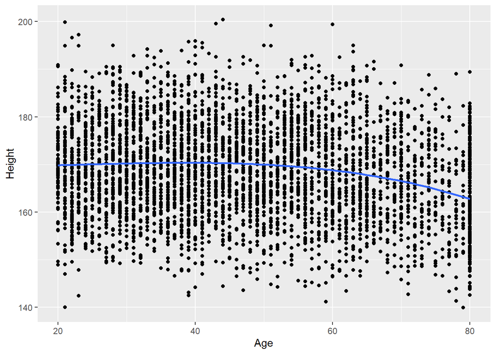

```r
#predict(model3, newdata = df)
k <- predict(model3, df)

ggplot(data = df) +
  geom_point(mapping = aes(x = Age, y = Height)) +
  geom_smooth(mapping = aes(x = Age, y = predict(model3, df)))
```

(a)의 model3에 따라 3차식으로 fitting된 scatterplot이다.

## (c)

`leaps` package를 사용한다.

```r
library(leaps)
model5.full <- regsubsets(Height ~ poly(Age, 5), data = df)
model5.full
```

```
## Subset selection object
## Call: regsubsets.formula(Height ~ poly(Age, 5), data = df)
## 5 Variables  (and intercept)
##               Forced in Forced out
## poly(Age, 5)1     FALSE      FALSE
## poly(Age, 5)2     FALSE      FALSE
## poly(Age, 5)3     FALSE      FALSE
## poly(Age, 5)4     FALSE      FALSE
## poly(Age, 5)5     FALSE      FALSE
## 1 subsets of each size up to 5
## Selection Algorithm: exhaustive
```

```r
summary(model5.full)
```

```
## Subset selection object
## Call: regsubsets.formula(Height ~ poly(Age, 5), data = df)
## 5 Variables  (and intercept)
##               Forced in Forced out
## poly(Age, 5)1     FALSE      FALSE
## poly(Age, 5)2     FALSE      FALSE
## poly(Age, 5)3     FALSE      FALSE
## poly(Age, 5)4     FALSE      FALSE
## poly(Age, 5)5     FALSE      FALSE
## 1 subsets of each size up to 5
## Selection Algorithm: exhaustive
##          poly(Age, 5)1 poly(Age, 5)2 poly(Age, 5)3 poly(Age, 5)4 poly(Age, 5)5
## 1  ( 1 ) "*"           " "           " "           " "           " "
## 2  ( 1 ) "*"           "*"           " "           " "           " "
## 3  ( 1 ) "*"           "*"           "*"           " "           " "
## 4  ( 1 ) "*"           "*"           "*"           "*"           " "
## 5  ( 1 ) "*"           "*"           "*"           "*"           "*"
```

nvmax option은 5개 변수만 사용하는 모델이 full model이므로 고려할 필요가 없다. 우선, 이를 통해 1개 변수만 사용할 때는 1차항만 사용(model1과 같음), 2개 변수만 사용할 때는 2차항까지만(model2와 같음), 3개 변수만 사용할 땐 3차항까지만(model3과 같음), 4개 변수만 사용할 때는 4차항까지만(model4와 같음) 사용하는 것이 각 변수 개수에서의 최고 모델임을 알 수 있다. 이제 이 중 어떤 모델을 선택할지 골라야 한다.

이 중 어떤 모델을 고르는 것이 적절한가? cross-vaildation, adjusted R squared, C_p, BIC 등 다양한 방법이 있다. 앞서 model 1~5를 adjusted r squared를 통해 비교하였으므로 이번에는 다른 방법을 사용한다.

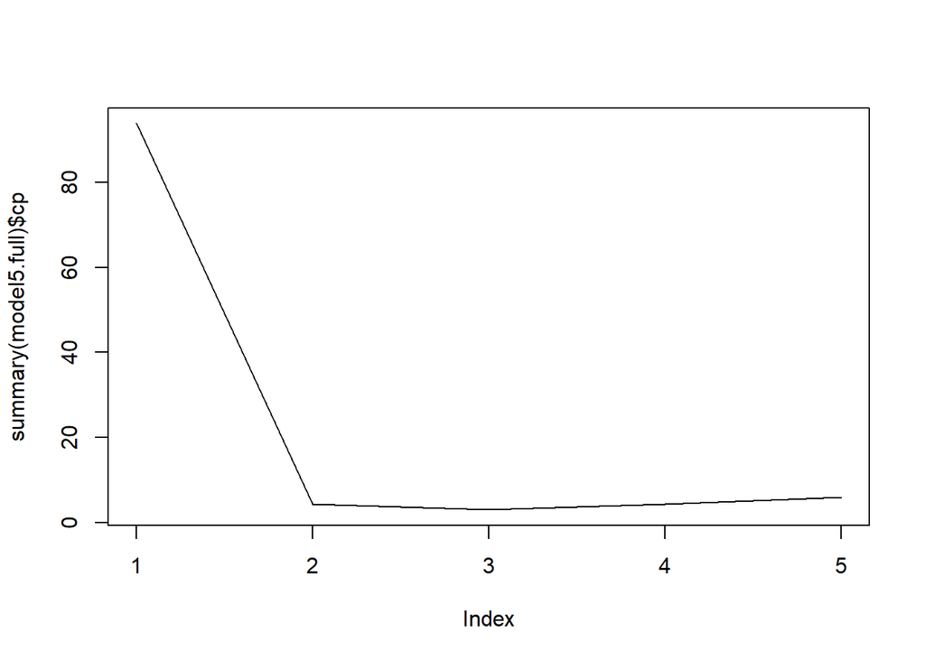

```r
plot(summary(model5.full)$cp, type = 'l')
```

```r
which.min(summary(model5.full)$cp)
```

```
## [1] 3
```

## (d)

### forward selection

```r
model5.forward <- regsubsets(Height ~ poly(Age, 5), data = df, method = 'forward')
model5.forward
```

```
## Subset selection object
## Call: regsubsets.formula(Height ~ poly(Age, 5), data = df, method = "forward")
## 5 Variables  (and intercept)
##               Forced in Forced out
## poly(Age, 5)1     FALSE      FALSE
## poly(Age, 5)2     FALSE      FALSE
## poly(Age, 5)3     FALSE      FALSE
## poly(Age, 5)4     FALSE      FALSE
## poly(Age, 5)5     FALSE      FALSE
## 1 subsets of each size up to 5
## Selection Algorithm: forward
```

```r
for.summary <- summary(model5.forward)
for.summary
```

```
## Subset selection object
## Call: regsubsets.formula(Height ~ poly(Age, 5), data = df, method = "forward")
## 5 Variables  (and intercept)
##               Forced in Forced out
## poly(Age, 5)1     FALSE      FALSE
## poly(Age, 5)2     FALSE      FALSE
## poly(Age, 5)3     FALSE      FALSE
## poly(Age, 5)4     FALSE      FALSE
## poly(Age, 5)5     FALSE      FALSE
## 1 subsets of each size up to 5
## Selection Algorithm: forward
##          poly(Age, 5)1 poly(Age, 5)2 poly(Age, 5)3 poly(Age, 5)4 poly(Age, 5)5
## 1  ( 1 ) "*"           " "           " "           " "           " "
## 2  ( 1 ) "*"           "*"           " "           " "           " "
## 3  ( 1 ) "*"           "*"           "*"           " "           " "
## 4  ( 1 ) "*"           "*"           "*"           "*"           " "
## 5  ( 1 ) "*"           "*"           "*"           "*"           "*"
```

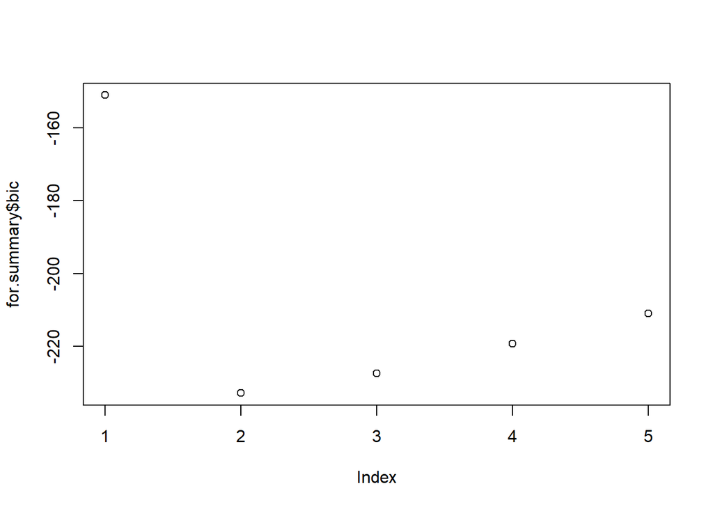

```r
plot(for.summary$bic)
```

```r
which.min(for.summary$bic)
```

```
## [1] 2
```

변수 개수별 best model은 앞의 결과와 똑같다. 이에 따라 각 복잡도멸 최고의 model을 BIC에 의해 구하면 위와 같다. model2를 이 경우 선택하게 된다.

### backward selection

```r
model5.backward <- regsubsets(Height ~ poly(Age, 5), data = df, method = 'backward')
model5.backward
```

```
## Subset selection object
## Call: regsubsets.formula(Height ~ poly(Age, 5), data = df, method = "backward")
## 5 Variables  (and intercept)
##               Forced in Forced out
## poly(Age, 5)1     FALSE      FALSE
## poly(Age, 5)2     FALSE      FALSE
## poly(Age, 5)3     FALSE      FALSE
## poly(Age, 5)4     FALSE      FALSE
## poly(Age, 5)5     FALSE      FALSE
## 1 subsets of each size up to 5
## Selection Algorithm: backward
```

```r
back.summary <- summary(model5.backward)
back.summary
```

```
## Subset selection object
## Call: regsubsets.formula(Height ~ poly(Age, 5), data = df, method = "backward")
## 5 Variables  (and intercept)
##               Forced in Forced out
## poly(Age, 5)1     FALSE      FALSE
## poly(Age, 5)2     FALSE      FALSE
## poly(Age, 5)3     FALSE      FALSE
## poly(Age, 5)4     FALSE      FALSE
## poly(Age, 5)5     FALSE      FALSE
## 1 subsets of each size up to 5
## Selection Algorithm: backward
##          poly(Age, 5)1 poly(Age, 5)2 poly(Age, 5)3 poly(Age, 5)4 poly(Age, 5)5
## 1  ( 1 ) "*"           " "           " "           " "           " "
## 2  ( 1 ) "*"           "*"           " "           " "           " "
## 3  ( 1 ) "*"           "*"           "*"           " "           " "
## 4  ( 1 ) "*"           "*"           "*"           "*"           " "
## 5  ( 1 ) "*"           "*"           "*"           "*"           "*"
```

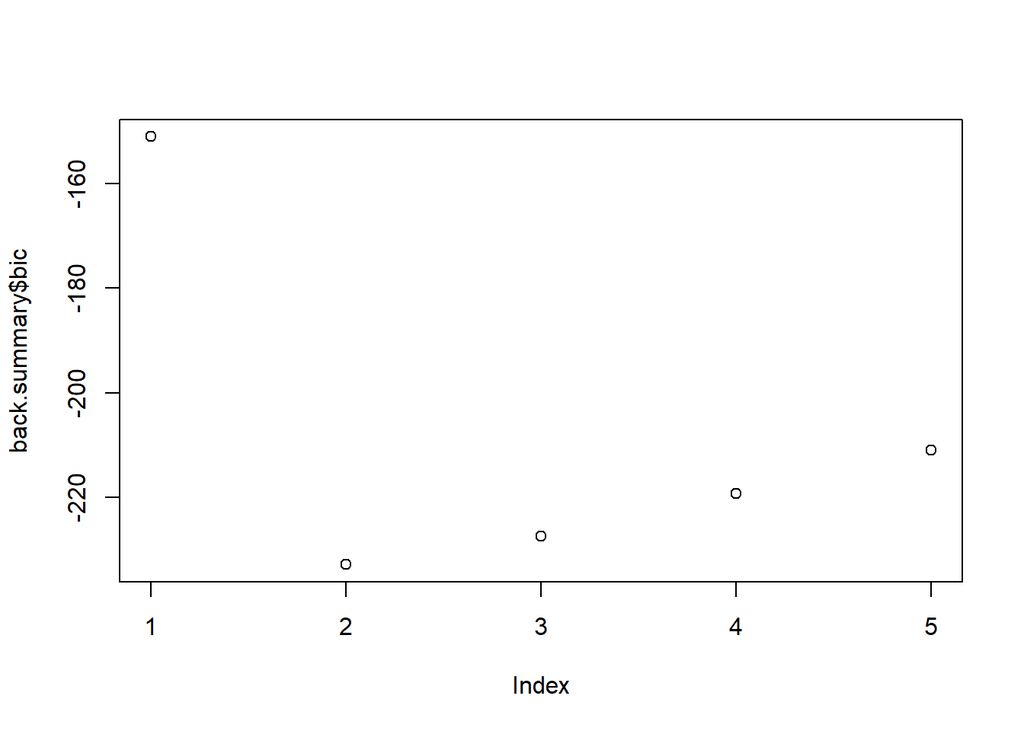

```r
plot(back.summary$bic)
```

```r
which.min(back.summary$bic)
```

```
## [1] 2
```

변수 개수별 best model은 앞의 결과와 똑같다. 이에 따라 각 복잡도멸 최고의 model을 BIC에 의해 구하면 위와 같다. 이 경우에도 model2를 선택하게 된다.

## (e)

```r
set.seed(42)

df_age <- model.matrix(Height ~ poly(Age, 5), data = df)[, -1]
df_height <- df$Height

df_train <- sample(1:nrow(df_age), nrow(df_age)/2)
df_test <- (-df_train)
height.test <- df_height[df_test]

cv.out <- cv.glmnet(df_age[df_train, ], df_height[df_train], alpha = 1)
bestlam <- cv.out$lambda.min
bestlam
```

```
## [1] 0.04961449
```

```r
lasso_model <- glmnet(df_age, df_height, alpha = 1, lambda = bestlam)
lasso_model
```

```
##
## Call:  glmnet(x = df_age, y = df_height, alpha = 1, lambda = bestlam)
##
##   Df %Dev  Lambda
## 1  5 3.93 0.04961
```

```r
summary(lasso_model)
```

```
##           Length Class     Mode
## a0        1      -none-    numeric
## beta      5      dgCMatrix S4
## df        1      -none-    numeric
## dim       2      -none-    numeric
## lambda    1      -none-    numeric
## dev.ratio 1      -none-    numeric
## nulldev   1      -none-    numeric
## npasses   1      -none-    numeric
## jerr      1      -none-    numeric
## offset    1      -none-    logical
## call      5      -none-    call
## nobs      1      -none-    numeric
```

```r
coef(lasso_model)
```

```
## 6 x 1 sparse Matrix of class "dgCMatrix"
##                        s0
## (Intercept)    169.074870
## poly(Age, 5)1 -125.583270
## poly(Age, 5)2  -90.116416
## poly(Age, 5)3  -14.065023
## poly(Age, 5)4   -4.048579
## poly(Age, 5)5    2.256133
```

bestlam의 결과는 위와 같이 출력되었다. (0.04961449)

# Exercise 2

## (a)

```r
lm1 <- glm(dia_yes ~ BMI, family = binomial, data = df)
summary(lm1)
```

```
##
## Call:
## glm(formula = dia_yes ~ BMI, family = binomial, data = df)
##
## Coefficients:
##              Estimate Std. Error z value Pr(>|z|)
## (Intercept) -4.570933   0.176264  -25.93   <2e-16 ***
## BMI          0.079042   0.005412   14.61   <2e-16 ***
## ---
## Signif. codes:  0 '***' 0.001 '**' 0.01 '*' 0.05 '.' 0.1 ' ' 1
##
## (Dispersion parameter for binomial family taken to be 1)
##
##     Null deviance: 4322.4  on 6561  degrees of freedom
## Residual deviance: 4111.0  on 6560  degrees of freedom
## AIC: 4115
##
## Number of Fisher Scoring iterations: 5
```

BMI의 1단위 증가(1 증가)는 로그오즈비가 0.079042만큼 증가한다는 것을 의미한다. 즉 BMI와 당뇨병은 전반적으로 양의 상관관계가 있다.

## (b)

```r
lm2 <- glm(dia_yes ~ BMI + male + Age, family = binomial, data = df)
coef(lm2)
```

```
## (Intercept)         BMI        male         Age
## -8.55644937  0.09646225  0.43098526  0.06035552
```

```r
lm3 <- glm(dia_yes ~ BMI + male + Age + white + black, family = binomial, data = df)
coef(lm3)
```

```
## (Intercept)         BMI        male         Age       white       black
## -8.30888501  0.09640955  0.45912688  0.06593039 -0.84654923 -0.06691055
```

```r
lm4 <- glm(dia_yes ~ BMI + male + Age + white + black + income_high + income_low, family = binomial, data = df)
coef(lm4)
```

```
## (Intercept)         BMI        male         Age       white       black
## -8.25074547  0.09433545  0.50374951  0.06418742 -0.75632438 -0.05832011
## income_high  income_low
## -0.19822672  0.30714832
```

```r
lm5 <- glm(dia_yes ~ BMI + male + Age + white + black + income_high + income_low + hs + own, family = binomial, data = df)
coef(lm5)
```

```
##  (Intercept)          BMI         male          Age        white        black
## -8.209721994  0.094256562  0.500632867  0.065986939 -0.724928450 -0.053559152
##  income_high   income_low           hs          own
## -0.166081007  0.261757622  0.001303713 -0.222204182
```

BMI의 coefficient는 0.09646225(lm2) -> 0.09640955(lm3) -> 0.09433545(lm4) -> 0.09425600(lm5)로 지속적으로 감소한다. 이는 추측컨대 `BMI`와 관계된 다른 변수인 hs, white, income_low, age 등이 지속적으로 추가되면서 BMI의 설명력이 감소하는 것에 따른 것일 것이다.

## (c)

```r
df2 <- df %>%
  cbind(1:nrow(df)) %>%
  rename(ids = '1:nrow(df)')

df2_test <- df2 %>% filter(ids%%10 == 0)
df2_train <- df2 %>% filter(ids%%10 != 0)
y.dia <- df2_test$dia_yes
```

그런데… MSE는 여기서 적절한 지표가 아니므로 다른 지표를 알아봐야 한다. Cross-Entropy Loss가 해결책이 될 수 있다. (-0.5777604, -0.6239781, -0.6294386, -0.6321395, -0.6306247)의 값이 (lm1, lm2, lm3, lm4, lm5)에서 각각 산출되며, 아래의 코드에서 확인할 수 있다.

이 경우 test set에서 cross-entropy loss의 mean이 낮은 lm4을 고르는 것이 바람직하다. 다른 set lm5의 경우 과적합된 것으로 보인다.

### lm1

```r
lm1.pr <- glm(dia_yes ~ BMI, family = binomial, data = df2_train)

yhat.lm1 <- predict.glm(lm1.pr, df2_test, type = 'response')
-mean(y.dia*log(yhat.lm1) + (1 - y.dia) * (1-yhat.lm1))
```

```
## [1] -0.5777604
```

### lm2

```r
lm2.pr <- glm(dia_yes ~ BMI + male + Age, family = binomial, data = df2_train)

yhat.lm2 <- predict.glm(lm2.pr, df2_test, type = 'response')
-mean(y.dia*log(yhat.lm2) + (1 - y.dia) * (1-yhat.lm2))
```

```
## [1] -0.6239781
```

### lm3

```r
lm3.pr <- glm(dia_yes ~ BMI + male + Age + white + black, family = binomial, data = df2_train)

yhat.lm3 <- predict.glm(lm3.pr, df2_test, type = 'response')
-mean(y.dia*log(yhat.lm3) + (1 - y.dia) * (1-yhat.lm3))
```

```
## [1] -0.6294386
```

### lm4

```r
lm4.pr <- glm(dia_yes ~ BMI + male + Age + white + black + income_high + income_low, family = binomial, data = df2_train)

yhat.lm4 <- predict.glm(lm4.pr, df2_test, type = 'response')
-mean(y.dia*log(yhat.lm4) + (1 - y.dia) * (1-yhat.lm4))
```

```
## [1] -0.6321395
```

### lm5

```r
lm5.pr <- glm(dia_yes ~ BMI + male + Age + white + black + income_high + income_low + hs + own, family = binomial, data = df2_train)

yhat.lm5 <- predict.glm(lm5.pr, df2_test, type = 'response')
-mean(y.dia*log(yhat.lm5) + (1 - y.dia) * (1-yhat.lm5))
```

```
## [1] -0.6306247
```